# Two-Way Analysis of Variance

Nicholas Wisniewski

May 3, 2016

# 1 Dataset

Let’s make up some frog data like in Drummond and Vowler’s *Analysis of variance: variably complex*. We are interested in seeing if diet has an impact on jumping distance in frogs. Here, 3 different species of frogs were given a diet based on superfoods, and a normal diet. If there is an effect due to the diet, can we tell if is it uniform across species, or if it affects different species differently?

```r
# Initialization
set.seed(100)
n <- 15
sigma <- 100

# Monte Carlo
BFnormal <- rnorm(n, mean=600, sd=sigma)
BFsuper <- rnorm(n, mean=600, sd=sigma)
LFnormal <- rnorm(n, mean=600, sd=sigma)
LFsuper <- rnorm(n, mean=650, sd=sigma)
TFnormal <- rnorm(n, mean=600, sd=sigma)
TFsuper <- rnorm(n, mean=800, sd=sigma)

# Put together into a dataframe
df <- data.frame(distance = c(BFnormal, BFsuper, LFnormal, LFsuper, TFnormal, TFsuper),
                 species = c(rep("Bullfrog", 2*n), rep("Leopardfrog", 2*n), rep("Treefrog", 2*n)),
                 diet =  rep(c(rep("normal", n), rep("superfood", n)), 3))
head(df,20)
```

```
##    distance  species      diet
## 1  549.7808 Bullfrog    normal
## 2  613.1531 Bullfrog    normal
## 3  592.1083 Bullfrog    normal
## 4  688.6785 Bullfrog    normal
## 5  611.6971 Bullfrog    normal
## 6  631.8630 Bullfrog    normal
## 7  541.8209 Bullfrog    normal
## 8  671.4533 Bullfrog    normal
## 9  517.4741 Bullfrog    normal
## 10 564.0138 Bullfrog    normal
## 11 608.9886 Bullfrog    normal
## 12 609.6274 Bullfrog    normal
## 13 579.8366 Bullfrog    normal
## 14 673.9840 Bullfrog    normal
## 15 612.3380 Bullfrog    normal
## 16 597.0683 Bullfrog superfood
## 17 561.1146 Bullfrog superfood
## 18 651.0856 Bullfrog superfood
## 19 508.6186 Bullfrog superfood
## 20 831.0297 Bullfrog superfood
```

First, let’s take a look at the data. If we look according to diet, we see that all species jump the same distance on a normal diet. However, when given superfoods, large differences appear in the mean distances each species can jump. This tells us there’s an interaction between species and diet.

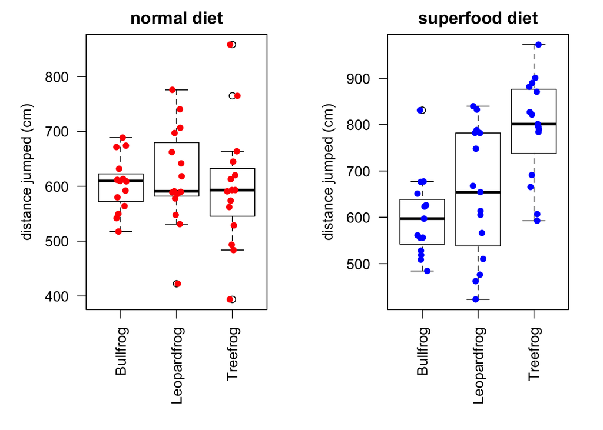

We want to test the null hypothesis, which is that all the groups were sampled from the same population. To do this, we specifically test the hypothesis that the group means are equal using ANOVA.

# 2 Two-Way ANOVA in R

The standard R function for ANOVA is the linear model: lm().

```r
model <- lm(distance ~ diet * species, data=df)
result <- anova(model)
pval.lm <- result$`Pr(>F)`
result
```

```
## Analysis of Variance Table
##
## Response: distance
##              Df Sum Sq Mean Sq F value    Pr(>F)
## diet          1 124008  124008 11.8188 0.0009145 ***
## species       2 133467   66734  6.3602 0.0026791 **
## diet:species  2 166498   83249  7.9342 0.0006978 ***
## Residuals    84 881365   10492
## ---
## Signif. codes:  0 '***' 0.001 '**' 0.01 '*' 0.05 '.' 0.1 ' ' 1
```

We see that the interaction is statistically significant. We should therefore be careful about interpreting the main effects (as seen in the boxplots of the marginals); we can tell from the interaction plot below that they only show up due to the interaction term.

Let’s look at the interaction plot. We notice that the species look the same while on a normal diet, but the effect of the superfood diet is different across species; there is an interaction.

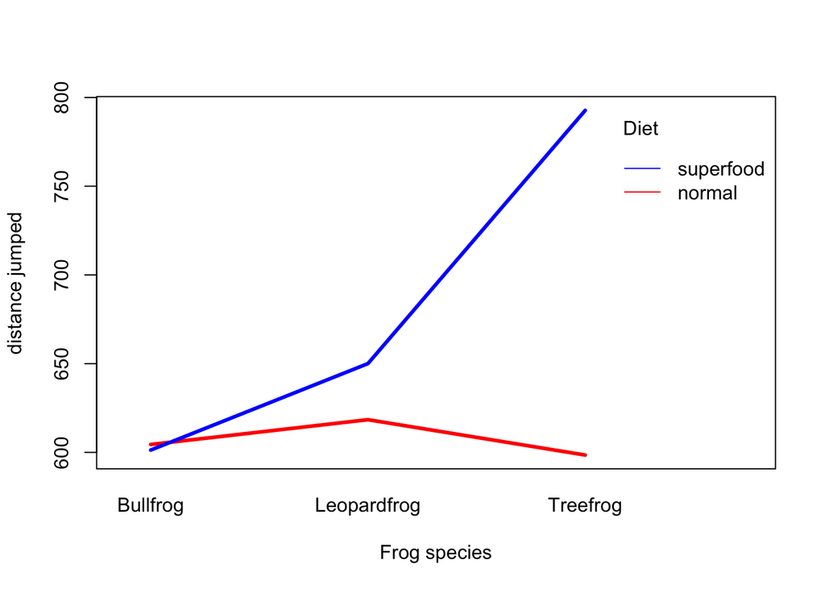

Let’s look at the marginal distributions, which represent the main effects of species and diet. Notice how the marginals can be misleading. The differences between species only appear with the superfood diet, so it is misleading to say that some species can jump farther in general (left). And the gain distance due to superfood (right) is not experienced by all species; bullfrogs are unaffected by superfood.

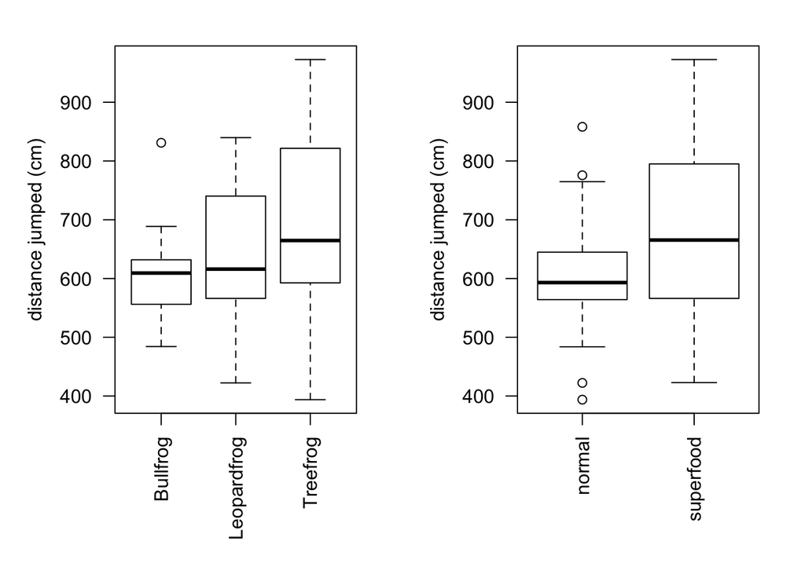

## 2.1 One-Way ANOVA: Interpreting the interaction

The significant interaction term suggests that we should not trust the main effects from the 2-way ANOVA. If diet affects different species differently, we should look at the effects in each species separately. We can do this by investigating the simple main effects found by using 1-way ANOVA on the subgroups.

First, we look for differences between diets in each frog species separately.

```r
df.species <- split(df, df$species)

anova(lm(distance ~ diet, data=df.species$Bullfrog)) # Bullfrogs
```

```
## Analysis of Variance Table
##
## Response: distance
##           Df Sum Sq Mean Sq F value Pr(>F)
## diet       1     74    73.8  0.0145 0.9051
## Residuals 28 142821  5100.7
```

```r
anova(lm(distance ~ diet, data=df.species$Leopardfrog)) # Leopardfrogs
```

```
## Analysis of Variance Table
##
## Response: distance
##           Df Sum Sq Mean Sq F value Pr(>F)
## diet       1   7502  7502.3  0.5352 0.4705
## Residuals 28 392521 14018.6
```

```r
anova(lm(distance ~ diet, data=df.species$Treefrog)) # Treefrogs
```

```
## Analysis of Variance Table
##
## Response: distance
##           Df Sum Sq Mean Sq F value    Pr(>F)
## diet       1 282930  282930  22.895 4.995e-05 ***
## Residuals 28 346023   12358
## ---
## Signif. codes:  0 '***' 0.001 '**' 0.01 '*' 0.05 '.' 0.1 ' ' 1
```

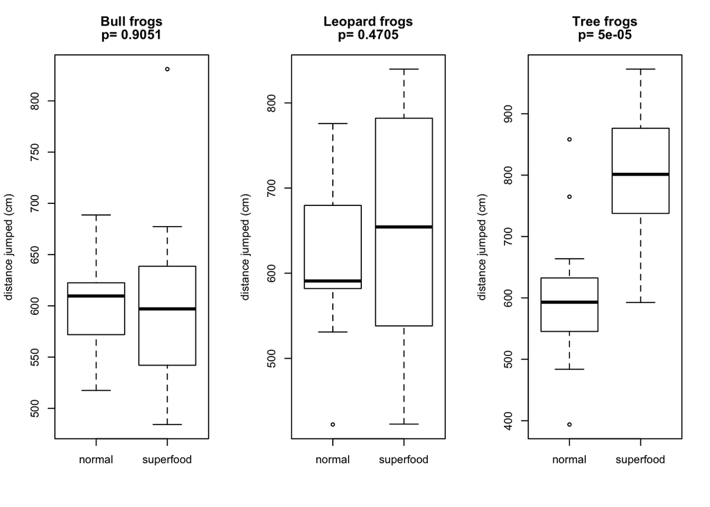

The diet has a statistically significant effect in treefrogs, but not the others. If there were several different diets, we would be interested in looking next at post-hoc t-tests. But there are only two diets in this experiment, so the 1-way ANOVA’s we just did were equivalent to t-tests.

Next, we look for differences between species in each diet group.

```r
df.diet <- split(df, df$diet)

anova(lm(distance ~ species, data=df.diet$normal)) # Normal diet
```

```
## Analysis of Variance Table
##
## Response: distance
##           Df Sum Sq Mean Sq F value Pr(>F)
## species    2   3145  1572.4  0.2053 0.8152
## Residuals 42 321738  7660.4
```

```r
anova(lm(distance ~ species, data=df.diet$superfood)) # Super diet
```

```
## Analysis of Variance Table
##
## Response: distance
##           Df Sum Sq Mean Sq F value    Pr(>F)
## species    2 296820  148410  11.138 0.0001316 ***
## Residuals 42 559628   13324
## ---
## Signif. codes:  0 '***' 0.001 '**' 0.01 '*' 0.05 '.' 0.1 ' ' 1
```

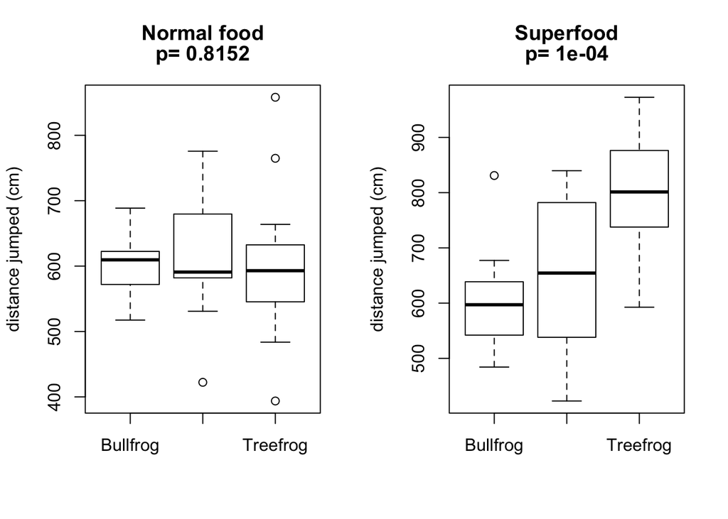

Frogs on the superfood diet have significant differences across frog species. But there is no difference between species on the normal diet.

This leads to the question: what are the differences between frog species in the superfood diet group? We already can tell that treefrogs jump farther than leopardfrogs, who jump faruther than bullfrogs. But to quantify this, we will do pairwise tests between each species.

### 2.1.1 Pairwise tests

We do the posthoc tests on the superfood diets:

```r
pairwise.t.test(df.diet$superfood$distance, df.diet$superfood$species, p.adjust="bonferroni") # Super diet
```

```
##
##  Pairwise comparisons using t tests with pooled SD
##
## data:  df.diet$superfood$distance and df.diet$superfood$species
##
##             Bullfrog Leopardfrog
## Leopardfrog 0.76184  -
## Treefrog    0.00014  0.00467
##
## P value adjustment method: bonferroni
```

The result shows that the treefrogs jump statistically significantly further than the rest, while the bullfrog and leopardfrog are not statistically significantly different.

## 2.2 Verifying assumptions

We could check the homogeneity of variance assumption using a test. If the data is normally distributed, the Bartlett test is the most powerful test to use. However, it is sensitive to data which is not non-normally distribution; it is more likely to return a “false positive” when the data is non-normal. There is also Levene’s test, which is more robust to departures from normality than Bartlett’s test. And finally, there is the Fligner-Killeen test, which is a non-parametric test that is very robust against departures from normality.

```r
bartlett.test(distance ~ interaction(diet,species), data=df)
```

```
##
##  Bartlett test of homogeneity of variances
##
## data:  distance by interaction(diet, species)
## Bartlett's K-squared = 14.352, df = 5, p-value = 0.01352
```

```r
fligner.test(distance ~ interaction(diet,species), data=df)
```

```
##
##  Fligner-Killeen test of homogeneity of variances
##
## data:  distance by interaction(diet, species)
## Fligner-Killeen:med chi-squared = 11.064, df = 5, p-value =
## 0.05013
```

```r
library(car)
leveneTest(distance ~ interaction(diet,species), data=df)
```

```
## Levene's Test for Homogeneity of Variance (center = median)
##       Df F value  Pr(>F)
## group  5  2.6536 0.02815 *
##       84
## ---
## Signif. codes:  0 '***' 0.001 '**' 0.01 '*' 0.05 '.' 0.1 ' ' 1
```

But there are also some plots to look at. The residual plot shows if there is a pattern in the residuals. It should indicate homoscedasticity. The next plot is a QQ plot that looks for normality of the residuals; if they are not normal, the assumptions of ANOVA are potentially violated. A third plot is a scale-location plot, which specifically looks at if the residuals increase with the fitted weights. Finally, the leverage plot gives an idea of which levels of the factor are best fitted.

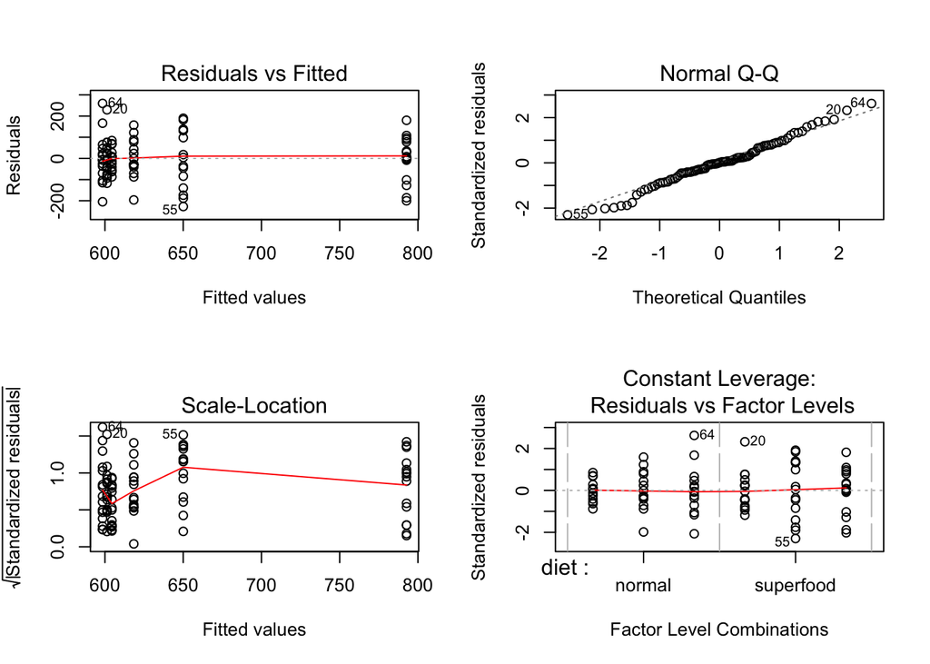

# 3 Nonparametric tests

No good R package exists. We can transform to ranks. Note that this is not recommended, as Monte Carlo studies by Sawilowsky show problems.

```r
model <- lm(rank(df$distance) ~ diet * species, data=df)
result <- anova(model)
pval.rank <- result$`Pr(>F)`
result
```

```
## Analysis of Variance Table
##
## Response: rank(df$distance)
##              Df Sum Sq Mean Sq F value   Pr(>F)
## diet          1   4509  4508.5  8.4042 0.004775 **
## species       2   4531  2265.4  4.2229 0.017884 *
## diet:species  2   6640  3320.1  6.1890 0.003109 **
## Residuals    84  45063   536.5
## ---
## Signif. codes:  0 '***' 0.001 '**' 0.01 '*' 0.05 '.' 0.1 ' ' 1
```

Again, we see an interaction.

## 3.1 One-Way ANOVA: Interpreting the interaction

We can do the one-way tests for each subroup. We begin with looking at diet in each species separately.

```r
kruskal.test(distance~diet, data=df.species$Bullfrog) # diet in bullfrogs
```

```
##
##  Kruskal-Wallis rank sum test
##
## data:  distance by diet
## Kruskal-Wallis chi-squared = 0.096774, df = 1, p-value = 0.7557
```

```r
kruskal.test(distance~diet, data=df.species$Leopardfrog) # diet in leopardfrogs
```

```
##
##  Kruskal-Wallis rank sum test
##
## data:  distance by diet
## Kruskal-Wallis chi-squared = 0.72301, df = 1, p-value = 0.3952
```

```r
kruskal.test(distance~diet, data=df.species$Treefrog) # diet in treefrogs
```

```
##
##  Kruskal-Wallis rank sum test
##
## data:  distance by diet
## Kruskal-Wallis chi-squared = 13.475, df = 1, p-value = 0.0002418
```

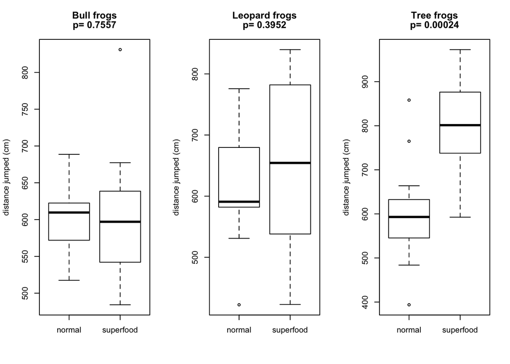

We see that there is a statistically significant difference in treefrogs between the mean distance jumped on normal diets and on superfood. This difference does not appear in the other frogs.

Next, we look at differences between species within each diet subgroup.

```r
kruskal.test(distance~species, data=df.diet$normal) # species differences in normal diet subgroup
```

```
##
##  Kruskal-Wallis rank sum test
##
## data:  distance by species
## Kruskal-Wallis chi-squared = 0.46918, df = 2, p-value = 0.7909
```

```r
kruskal.test(distance~species, data=df.diet$superfood) # species differences in superfood diet subgroup
```

```
##
##  Kruskal-Wallis rank sum test
##
## data:  distance by species
## Kruskal-Wallis chi-squared = 14.744, df = 2, p-value = 0.0006286
```

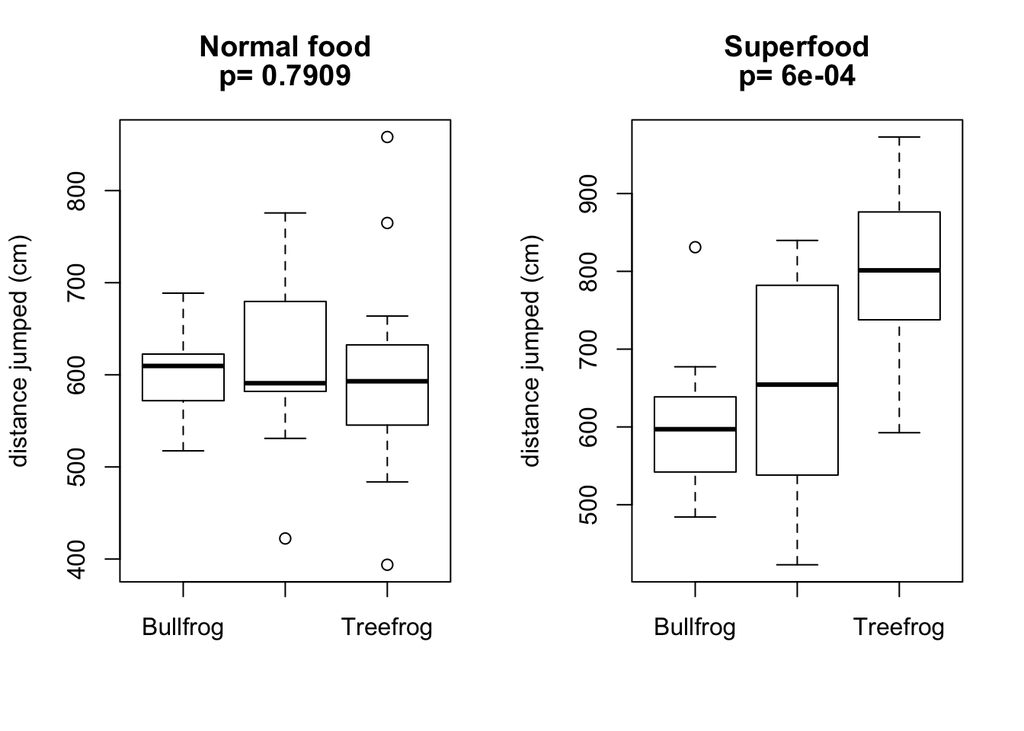

We see that there is a statistically significant difference between species in the superfood subgroup. To quantify these differences, we will use nonparametric post-hoc tests.

### 3.1.1 Pairwise tests

For post-hoc testing, we can use pairwise Mann-Whitney U tests. We look for differences between species in the superfood group.

```r
pairwise.wilcox.test(df.diet$superfood$distance, df.diet$superfood$species, p.adjust="bonferroni") # Superfood
```

```
##
##  Pairwise comparisons using Wilcoxon rank sum test
##
## data:  df.diet$superfood$distance and df.diet$superfood$species
##
##             Bullfrog Leopardfrog
## Leopardfrog 1.00000  -
## Treefrog    0.00034  0.01280
##
## P value adjustment method: bonferroni
```

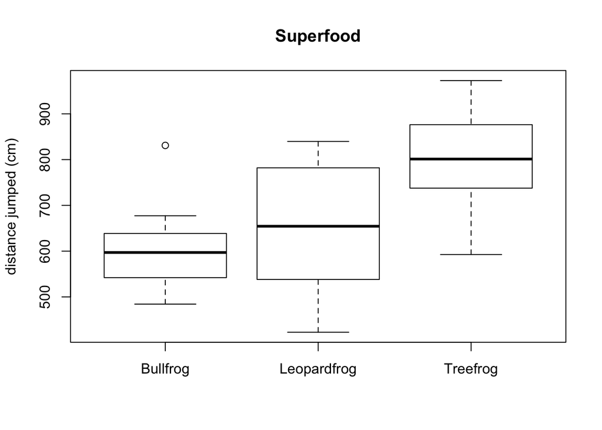

We see that treefrogs are different from the rest.

# 4 Bootstrap tests

Let’s construct a more general bootstrap ANOVA for ourselves. First, let’s define some preliminary functions to compute the sum of squares, sum of abs, and the F-like statistic:

```r
# Define functions to compute the Sum of Squares, and Sum of Abs
ssq <- function(x) sum(x^2)
sab <- function(x) sum(abs(x))

# A more general function to compute the F-statistic
Fstat.2way <- function( X, f1, f2, center=mean, agg=ssq, rank=FALSE) {
    if (rank==FALSE){Y = X} else{Y = rank(-X)}
    mu = center(Y)  #Grand Mean
    groupMeans.f1 = ave( Y, f1, FUN=center ) #Pool f1
    groupMeans.f2 = ave( Y, f2, FUN=center ) #Pool f2
    groupMeans.int = ave( Y, f1, f2, FUN=center ) #Cell means
    SSB.f1 = agg(groupMeans.f1 - mu)
    SSB.f2 = agg(groupMeans.f2 - mu)
    SSB.int = agg( groupMeans.int - (groupMeans.f1 + groupMeans.f2 - mu) )
    SSW = agg(Y - groupMeans.int)
    return( c(f1=SSB.f1 , f2=SSB.f2, int=SSB.int) /  SSW )
}
```

## 4.1 F-statistic using L2-norm (sum of squared deviations around the mean)

Now let’s implement the bootstrap using the mean and sum of squares:

```r
X <- df$distance
f1 <- df$diet
f2 <- df$species
deals <- 10000

F0 <- Fstat.2way(X, f1, f2, center=mean, agg=ssq, rank=F)
bootF <- matrix(NA, nrow=deals, ncol=3) #preallocate
for(i in 1:deals){
    bootX <- sample(X, replace=T)
    bootF[i,] <- Fstat.2way(bootX, f1, f2, center=mean, agg=ssq, rank=F)
}
pval.L2 <- colSums(sweep(bootF, 2, F0,"-") > 0) / deals
```

Take a look at the null distribution for the F statistic:

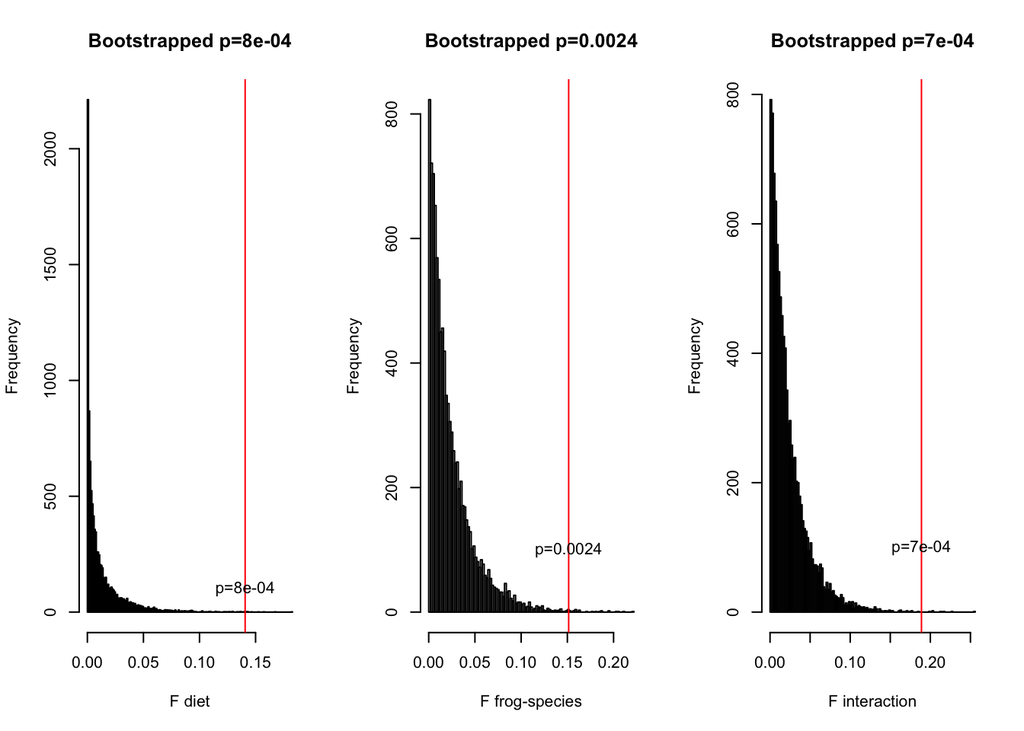

## 4.2 F-statistic using L1-norm (sum of absolute deviations around the mean)

Now let’s implement the bootstrap using the mean and sum of absolute deviations:

```r
F0 <- Fstat.2way(X, f1, f2, center=mean, agg=sab, rank=F)
bootF <- matrix(NA, nrow=deals, ncol=3) #preallocate
for(i in 1:deals){
    bootX <- sample(X, replace=T)
    bootF[i,] <- Fstat.2way(bootX, f1, f2, center=mean, agg=sab, rank=F)
}
pval.L1 <- colSums(sweep(bootF, 2, F0,"-") > 0) / deals
```

Take a look at the null distribution for the F statistic. We get a very similar p-value:

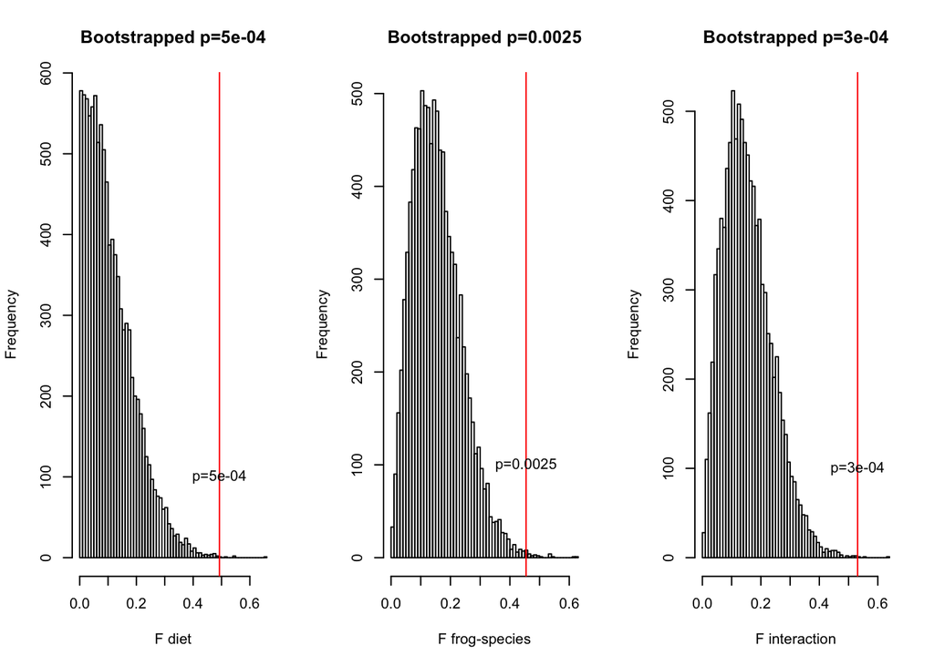

## 4.3 Rank test

Now let’s implement the bootstrap using ranks:

```r
# Run it on the dataframe to get the test statistic:
F0 <- Fstat.2way(X, f1, f2, center=mean, agg=ssq, rank=T)
bootF <- matrix(NA, nrow=deals, ncol=3) #preallocate
for(i in 1:deals){
    bootX <- sample(X, replace=T)
    bootF[i,] <- Fstat.2way(bootX, f1, f2, center=mean, agg=ssq, rank=T)
}
pval.rankboot <- colSums(sweep(bootF, 2, F0,"-") > 0) / deals
```

Take a look at the null distribution for the F statistic. We get a very similar p-value:

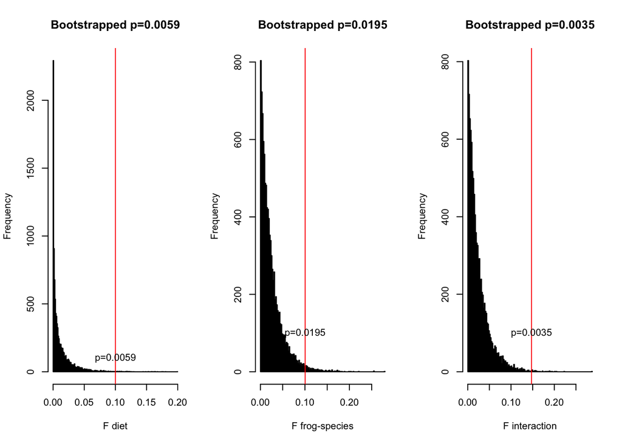

# 5 P-value comparison

Here we compare the p-values that were generated by each method. The bootstrap using the L1-norm (sum of absolute deviations from the mean) looks to be the most powerful. The rank tests have the worst power, and are known to give unreliable results for multifactorial ANOVA.

|  | diet | species | interaction |
| --- | --- | --- | --- |
| built-in ANOVA | 0.0009 | 0.0027 | 0.0007 |
| bootstrap with L1-norm | 0.0005 | 0.0025 | 0.0003 |
| bootstrap with L2-norm | 0.0008 | 0.0024 | 0.0007 |
| rank | 0.0048 | 0.0179 | 0.0031 |
| bootstrap rank | 0.0059 | 0.0195 | 0.0035 |